# tidyverse

##### 6.1.8 Scaterplot: lines

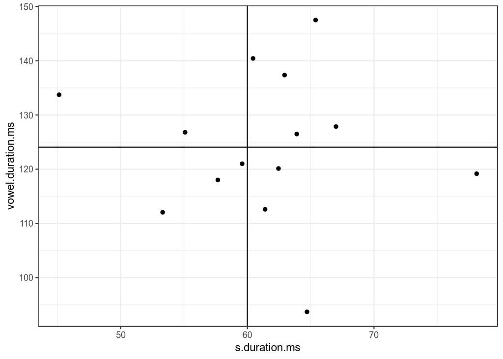

```r
homo %>%
  ggplot(aes(s.duration.ms, vowel.duration.ms)) +
  geom_point() +
  geom_hline(yintercept = mean(homo$vowel.duration.ms))+
  geom_vline(xintercept = 60)
```

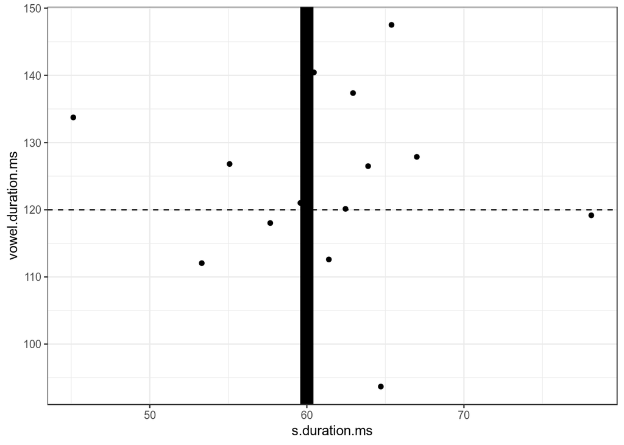

```r
homo %>%
  ggplot(aes(s.duration.ms, vowel.duration.ms)) +
  geom_point() +
  geom_hline(yintercept = 120, linetype = 2)+
  geom_vline(xintercept = 60, size = 5)
```

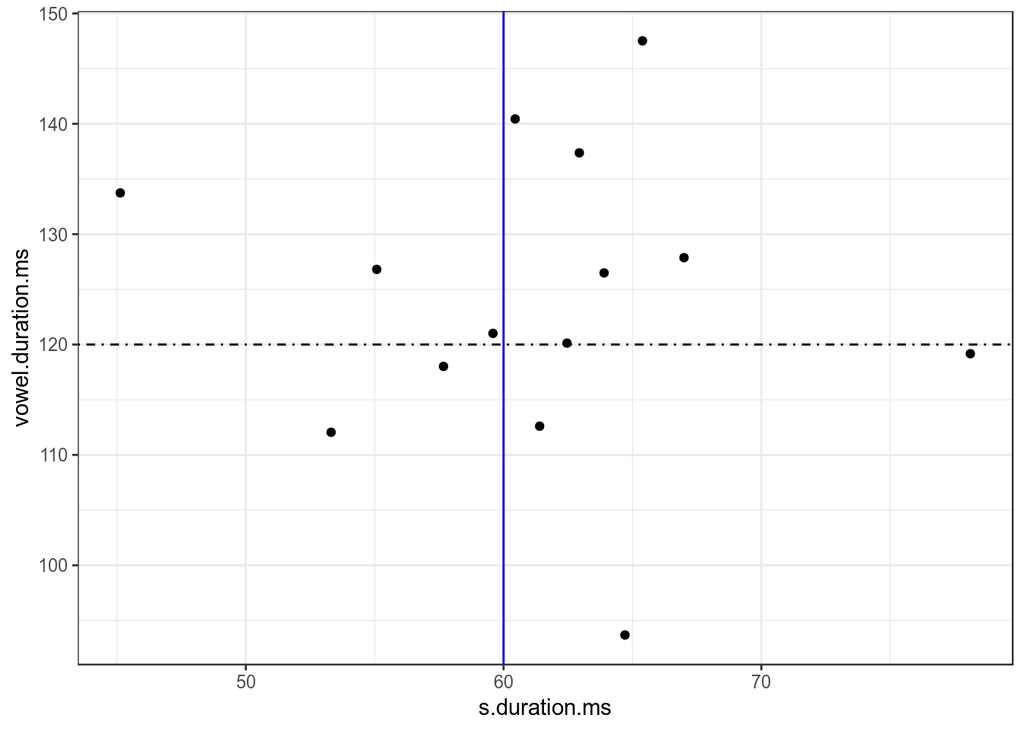

```r
homo %>%
  ggplot(aes(s.duration.ms, vowel.duration.ms)) +
  geom_point() +
  geom_hline(yintercept = 120, linetype = 4)+
  geom_vline(xintercept = 60, color = "blue")
```

##### 6.1.9 Scaterplot: annotate

Функция `annotate` добавляет `geom` к графику.

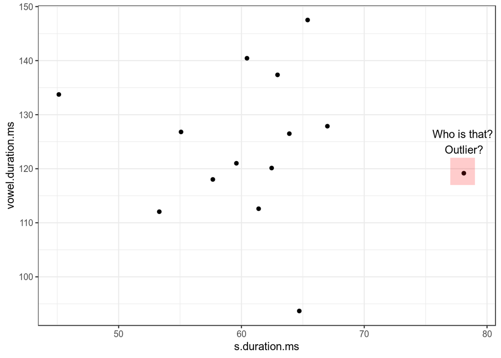

```r
homo %>%
  ggplot(aes(s.duration.ms, vowel.duration.ms)) +
  geom_point()+
  annotate(geom = "rect", xmin = 77, xmax = 79,
           ymin = 117, ymax = 122, fill = "red", alpha = 0.2) +
  annotate(geom = "text", x = 78, y = 125,
           label = "Who is that?\n Outlier?")
```

##### Task 6

In dataset `diamonds` calculate mean value of the variable `price` for each `cut` and visualise it using argument `shape = 5`.

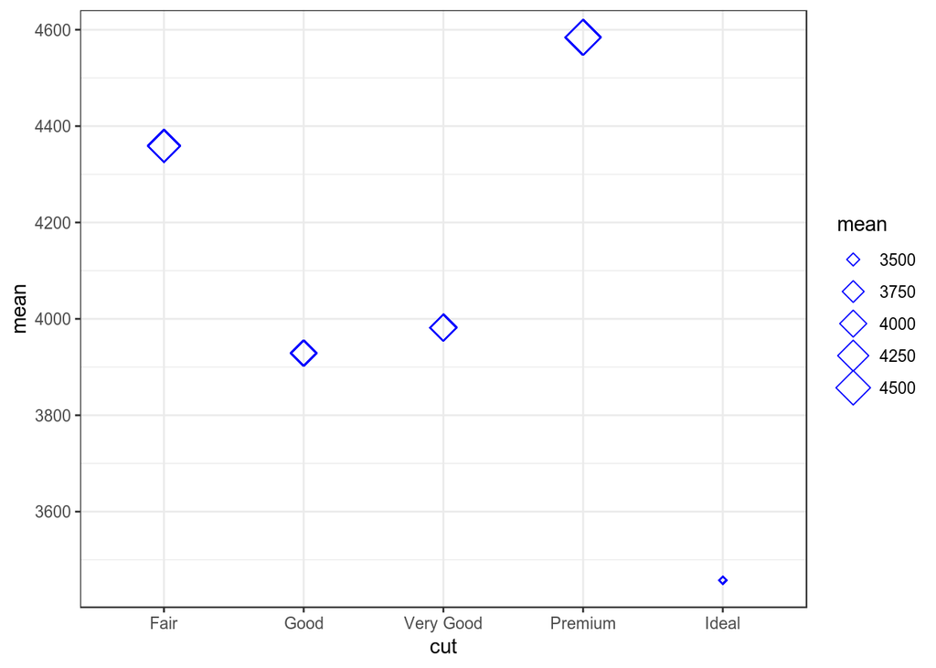

#### 6.2 Barplots

There are two possible situations:

- not aggregate data

```r
head(homo[, c(1, 9)])
```

| speaker | orientation |
| --- | --- |
| A | hetero |
| B | hetero |
| C | homo |
| D | homo |
| E | homo |
| F | homo |

- aggregate data

```r
head(homo[, c(1, 10)])
```

| speaker | age |
| --- | --- |
| A | 30 |
| B | 19 |
| C | 29 |
| D | 36 |
| E | 27 |
| F | 33 |

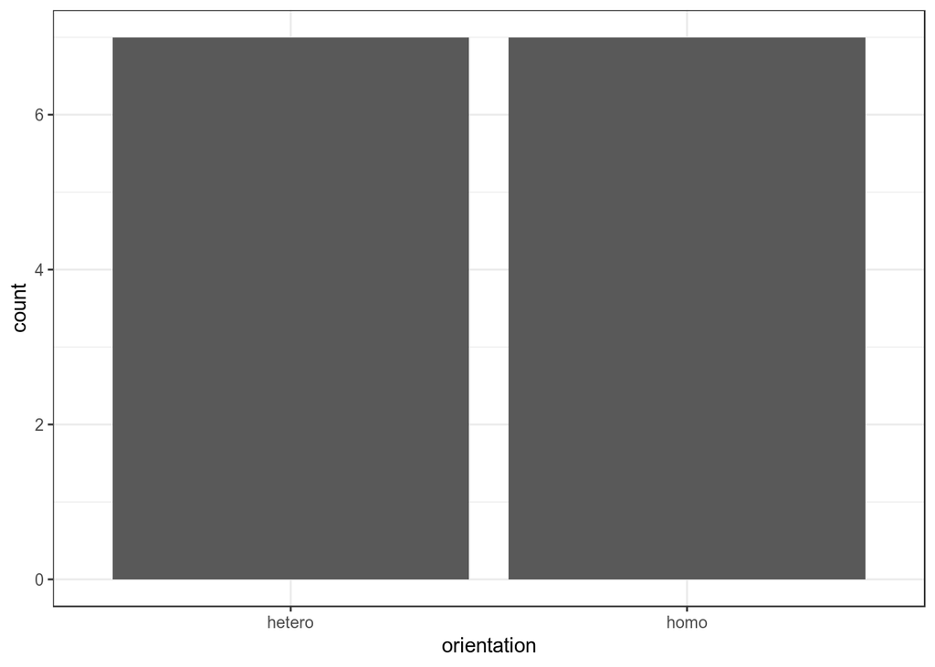

```r
homo %>%
  ggplot(aes(orientation)) +
  geom_bar()
```

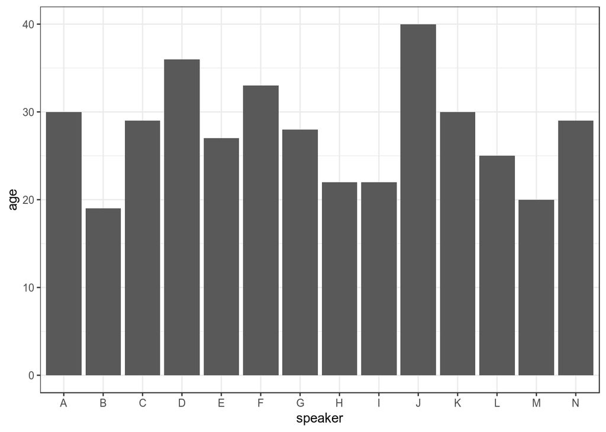

```r
homo %>%
  ggplot(aes(speaker, age)) +
  geom_col()
```

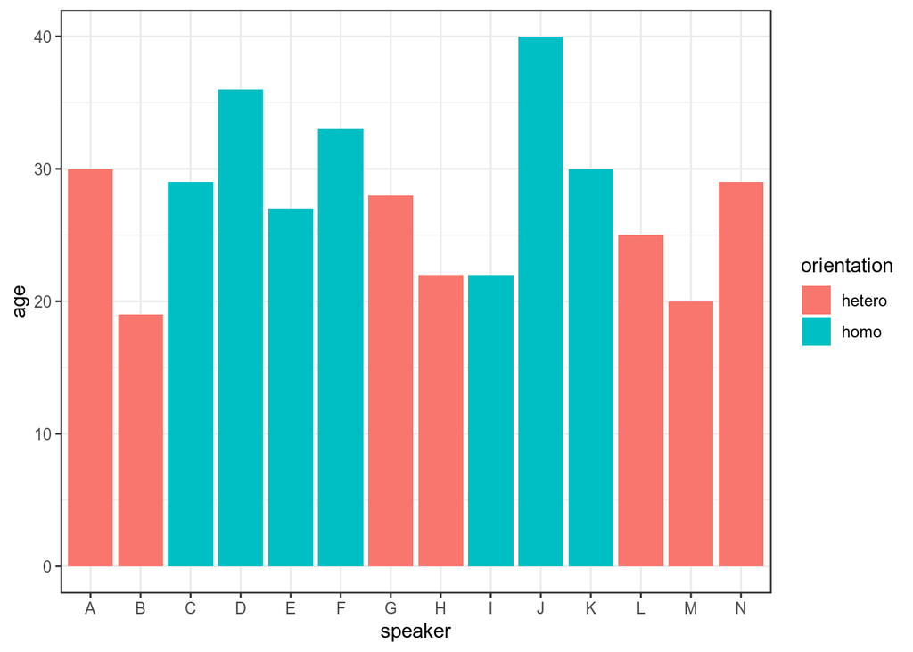

```r
homo %>%
  ggplot(aes(speaker, age, fill = orientation)) +
  geom_col()
```

#### 6.3 Boxplots: basics, points, jitter

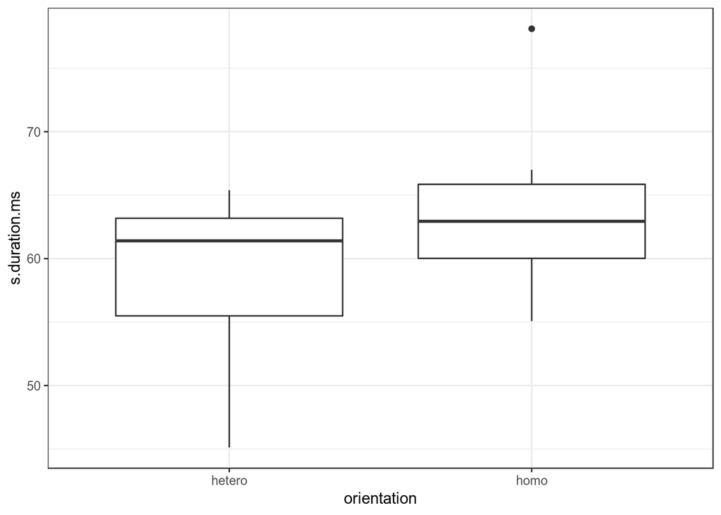

```r
homo %>%
  ggplot(aes(orientation, s.duration.ms)) +
  geom_boxplot()
```

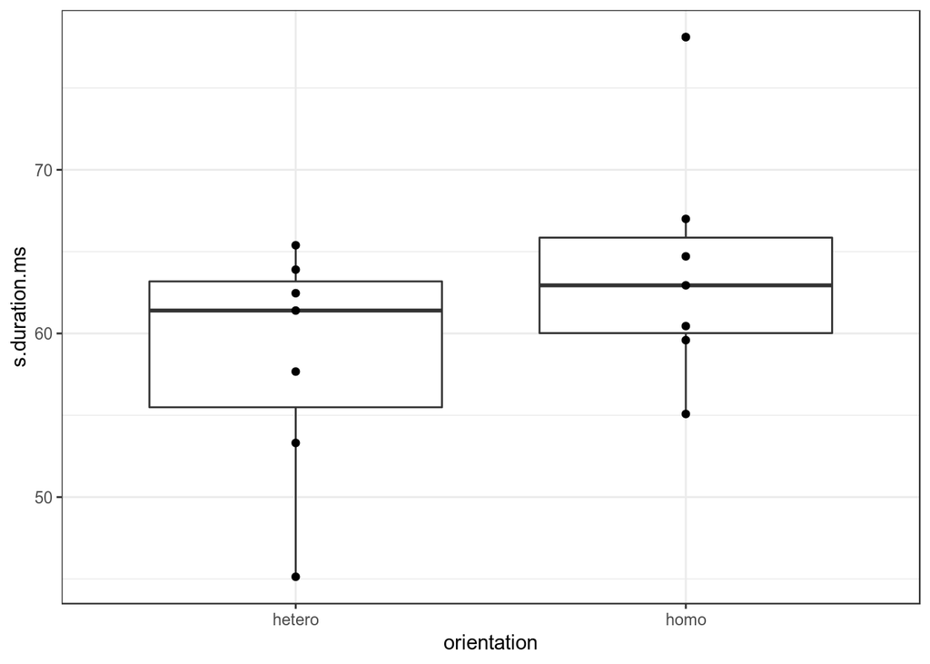

```r
homo %>%
  ggplot(aes(orientation, s.duration.ms)) +
  geom_boxplot()+
  geom_point()
```

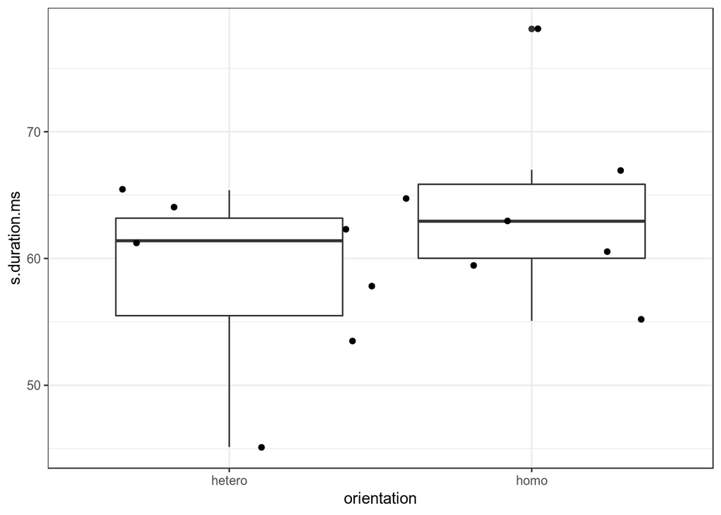

```r
homo %>%
  ggplot(aes(orientation, s.duration.ms)) +
  geom_boxplot() +
  geom_jitter(width = 0.5)
```

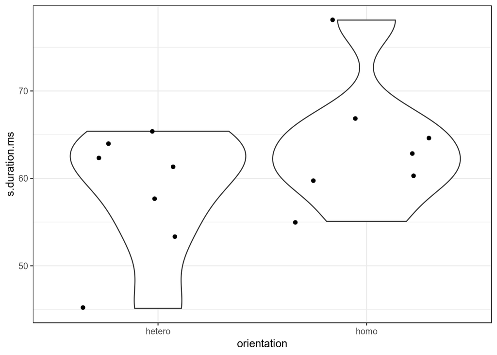

```r
homo %>%
  ggplot(aes(orientation, s.duration.ms)) +
  geom_violin() +
  geom_jitter()
```

##### Task 7

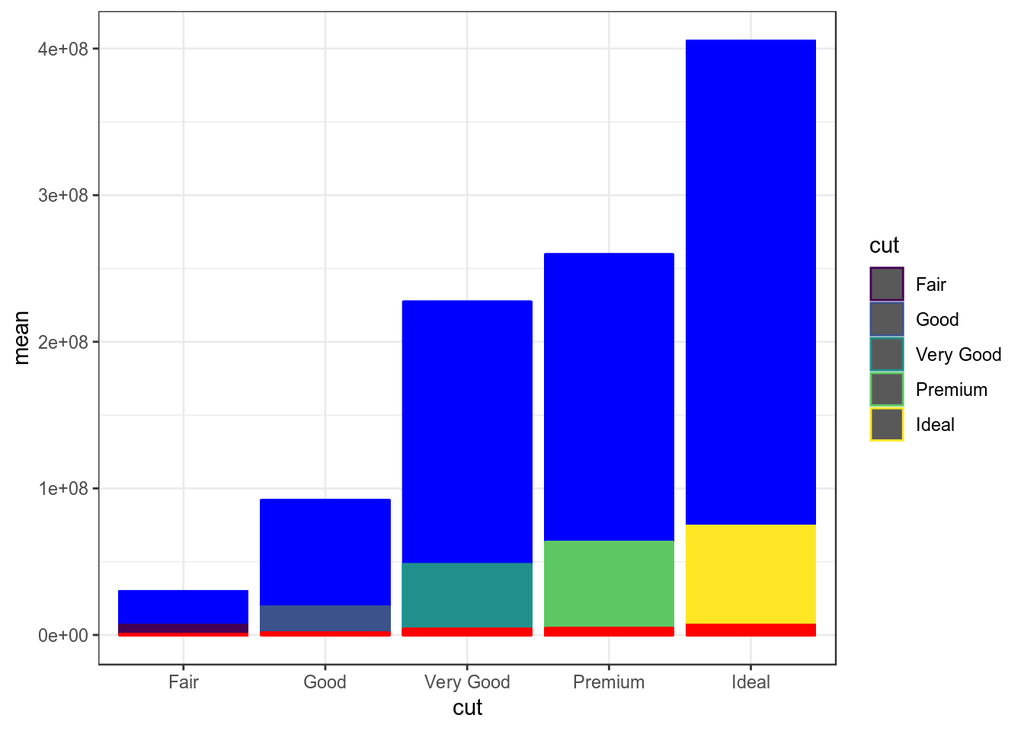

#### 6.1-3 Preliminary summary: two variables

- scaterplot: two quantitative varibles
- barplot: nominal varible and one number
- boxplot: nominal varible and quantitative varibles
- jittered points or sized points: two nominal varibles

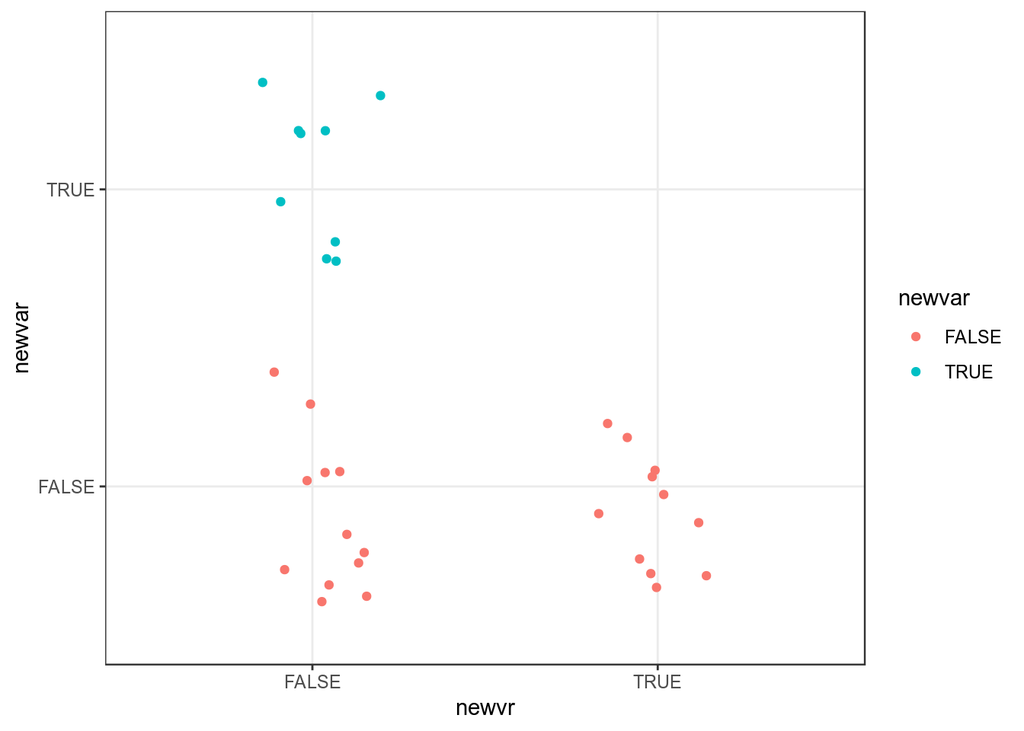

```r
mtcars %>%
  mutate(newvar = mpg > 22,
         newvr = mpg < 17) %>%
  ggplot(aes(newvr, newvar, color = newvar))+
  geom_jitter(width = 0.2)
```

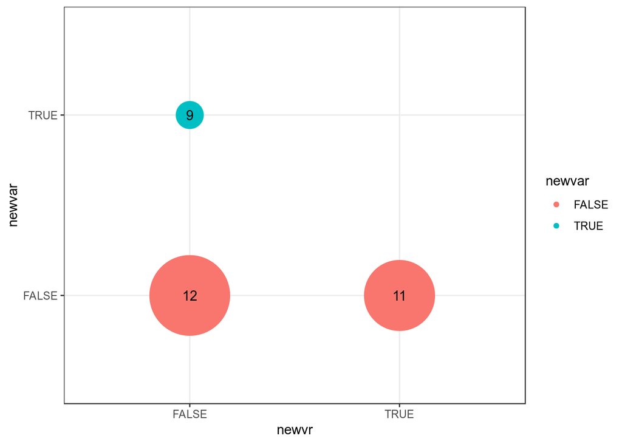

```r
mtcars %>%
  mutate(newvar = mpg > 22,
         newvr = mpg < 17) %>%
  group_by(newvar, newvr) %>%
  summarise(number = n()) %>%
  ggplot(aes(newvr, newvar, label = number))+
  geom_point(aes(size = number, color = newvar))+
  geom_text()+
  scale_size(range = c(10, 30))+
  guides(size = F)
```

#### 6.4 Histogram

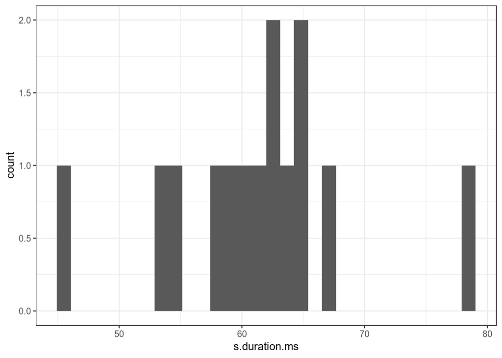

```r
homo %>%
  ggplot(aes(s.duration.ms)) +
  geom_histogram()
```

How many histogram bins do we need?

- [Sturgers 1926] `nclass.Sturges(homo$s.duration.ms)`
- [Scott 1979] `nclass.scott(homo$s.duration.ms)`
- [Freedman, Diaconis 1981] `nclass.FD(homo$s.duration.ms)`

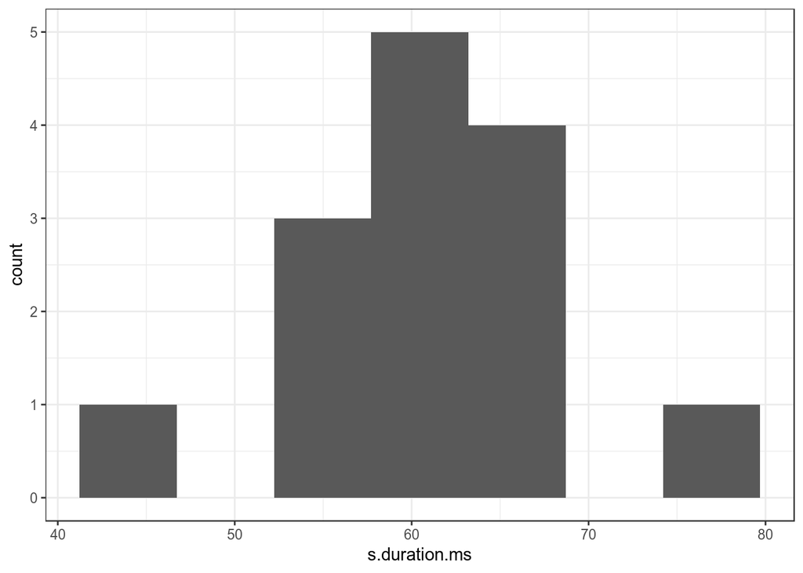

```r
homo %>%
  ggplot(aes(s.duration.ms)) +
  geom_histogram(bins = nclass.FD(homo$s.duration.ms))
```

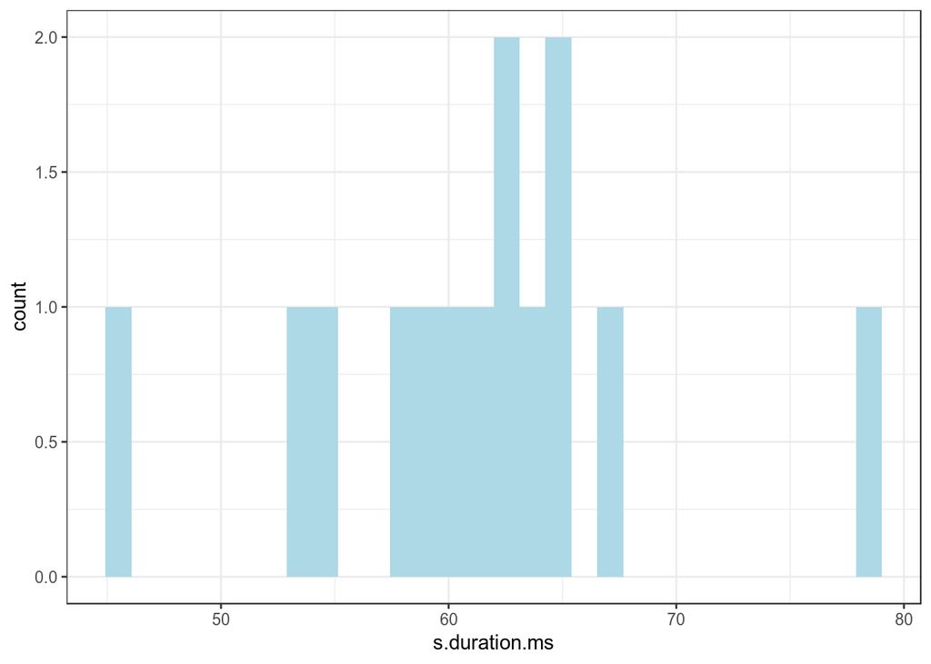

```r
homo %>%
  ggplot(aes(s.duration.ms)) +
  geom_histogram(fill = "lightblue")
```